# Multiple Patient Prediction

# Introduction

This notebook provides a running example for predicting the following for a set of currently hospitalized patients:

1. The expected number of hospitalized patients per day.
2. The expected number of patients in a Critical state (named “Critical” in the paper, but `SEVERE` in code).
3. The expected number of deceased patients by days since hospitalization, in 5 day intervals.

We also show how you could test different future scenarios by loading a set of future hospitalizations you defined.

# Initializations:

### Load pre-fit model:

```r
model = readRDS('./cache/israeli_model.Rds')
```

### Set Monte Carlo Parameters

```r
# the number of simulated runs per patient, 10K is our recommendation
N_MONTE_CARLO_RUNS = 10*1000

# the maximum number of transitions in the Multi-State model
# this is used to exclude outlier paths with more transitions than
# the maximal number of transitions observed in the data
MAX_PATH_LENGTH = 9
```

### Define `T`: the day from which we predict

```r
T = Sys.Date() # use the date of today
PREDICT_N_DAYS_AHEAD = 30 # predict one month ahead
```

# Load Hospitalized Patient Data:

In this example we generate **random stub data**, but you can use your own data by reading a dataframe which complies with the following conventions:

1. `sex`: MALE (1), FEMALE (0)
2. `age`: in years
3. `state_at_hospitalization`: either `MILD` (2), `MODERATE` (3) or `SEVERE` (4). Note, these correspond with the states Moderate, Severe, Critical which are used in the paper
4. `date_of_hospitalization`: date in the format ‘yyyy-mm-dd’
5. `current_state`: same values as 3 above
6. `days_spent_in_current_state`: non-negative integer
7. `was_severe`: Binary indicator. Visited severe state at least once before entering the current state (1), or not (0)

**Note:** The data generated here is not intended to reflect any true distribution of patients but only serves as an example of the needed data **format**. Do not base predictions on this stub data.

```r
hospitalized_patients_df = generate_random_hospitalized_patients_df(n_hospitalized_patients = 30,
                                                                    T = T,
                                                                    PREDICT_N_DAYS_AHEAD = PREDICT_N_DAYS_AHEAD)


# alternatively:
# hospitalized_patients_df = read.csv('sourasky_arrival_df.csv')

formattable(head(hospitalized_patients_df, n=5))
```

| sex | age | state_at_hospitalization | date_of_hospitalization | current_state | days_spent_in_current_state | was_severe |
| --- | --- | --- | --- | --- | --- | --- |
| 1 | 69 | 3 | 2020-10-15 | 3 | 5 | FALSE |
| 1 | 75 | 3 | 2020-10-16 | 4 | 2 | FALSE |
| 1 | 41 | 2 | 2020-10-14 | 2 | 3 | FALSE |
| 1 | 65 | 3 | 2020-10-18 | 3 | 2 | FALSE |
| 0 | 10 | 2 | 2020-10-17 | 2 | 3 | FALSE |

### Convert Table into the Format Acceptable by the Model:

```r
hospitalized_patients = lapply(1:nrow(hospitalized_patients_df), function(row_idx) {

  row = hospitalized_patients_df[row_idx,]

  construct_patient_object(
    sex = row$sex,
    age = row$age,
    state_at_hospitalization = row$state_at_hospitalization,
    date_of_hospitalization = row$date_of_hospitalization,
    current_state = row$current_state,
    days_spent_in_current_state = row$days_spent_in_current_state,
    was_severe  = row$was_severe,
    T=T
  )
})
```

## Load Future Arrival Data:

**Note:** The stub data generated here is not intended to reflect any true distribution of patients but only serves as an example of the needed data **format**. Do not base predictions on this stub data.

```r
future_arrival_patients_df = generate_future_arrival_patients_df(n_future_arrivals = 100,
                                                                 T = T,
                                                                 PREDICT_N_DAYS_AHEAD = PREDICT_N_DAYS_AHEAD)

# alternatively:
# future_arrival_patients_df = read.csv('PATH TO YOUR FUTURE ARRIVAL SCENARIO CSV')


formattable(head(future_arrival_patients_df, n=5))
```

| sex | age | state_at_hospitalization | date_of_hospitalization |
| --- | --- | --- | --- |
| 1 | 62 | 2 | 2020-11-12 |
| 1 | 84 | 4 | 2020-11-06 |
| 1 | 39 | 3 | 2020-11-02 |
| 1 | 78 | 3 | 2020-11-14 |
| 0 | 34 | 4 | 2020-10-29 |

```r
future_arrival_patients = lapply(1:nrow(future_arrival_patients_df), function(row_idx) {

  row = future_arrival_patients_df[row_idx, ]

  construct_future_arrival_patient_object(
    sex = row$sex,
    age = row$age,
    state_at_hospitalization = row$state_at_hospitalization,
    date_of_hospitalization = row$date_of_hospitalization
  )
})
```

### Merge the two lists of patients, and perform a monte carlo simulation per patient

```r
INCLUDE_FUTURE_ARRIVAL_PATIENTS = TRUE
```

```r
all_patients = hospitalized_patients
if (INCLUDE_FUTURE_ARRIVAL_PATIENTS) all_patients = append(all_patients,
                                                           future_arrival_patients)

all_patients = run_monte_carlo_per_patient(all_patients,
                                           N_MONTE_CARLO_RUNS,
                                           MAX_PATH_LENGTH)
```

# Plot the number of hospitalized patients per day

The plots below displays the mean number of hospitalized patients, over all monte carlo simulations.

For each day, we plot:

- mean number of hospitalized patients
- 25 to 75 quantiles of number of hospitalized patients (red fill)
- 10 to 90 quantiles of number of hospitalized patients (orange fill)

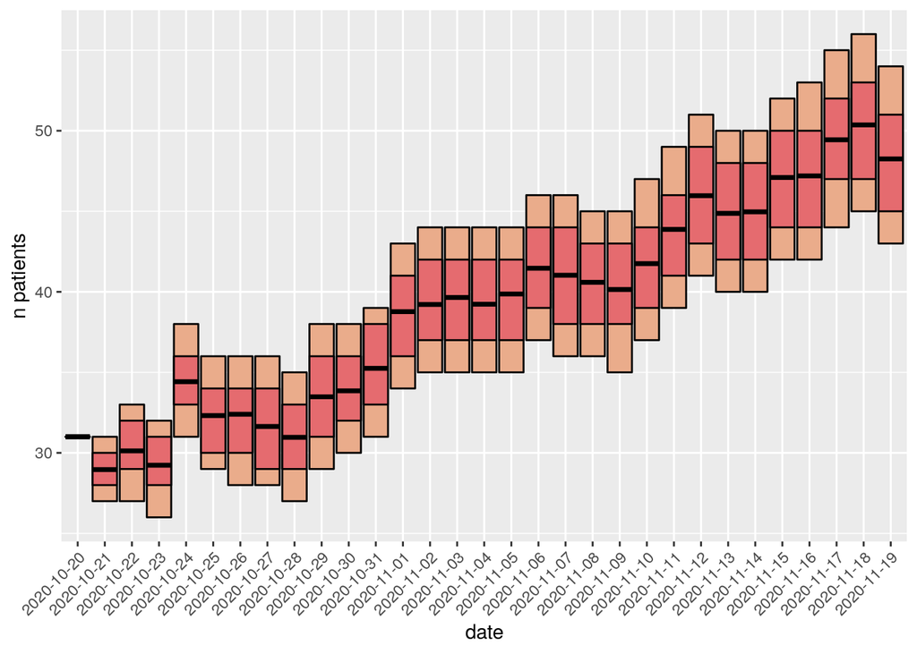

# Plot the number of patients hospitalized at SEVERE state per day

The plot below is simialr to that above, except it displays the mean number of hospitalized patients **in a Critical state** (`SEVERE`)

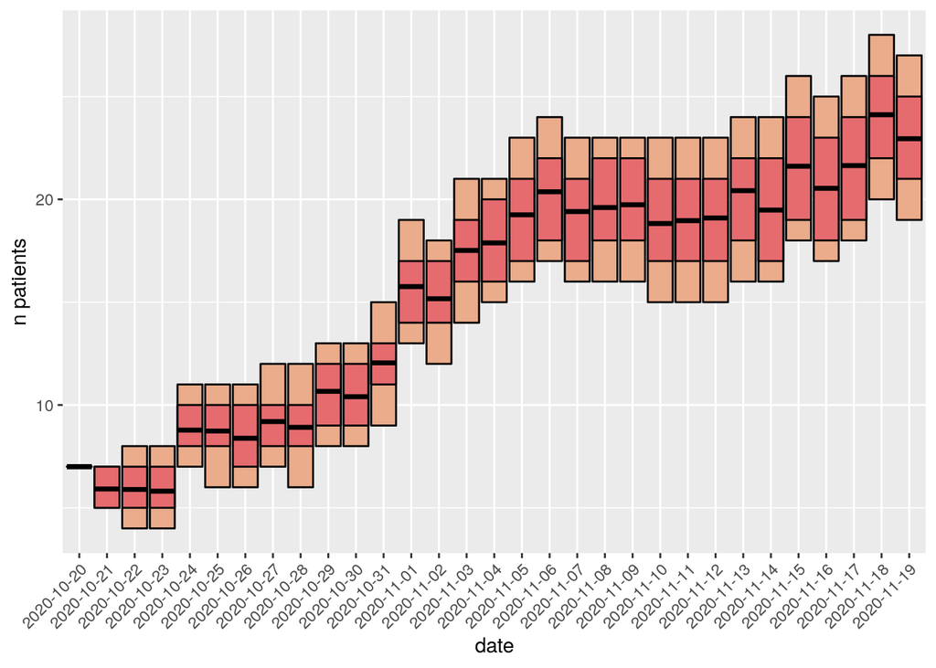

```r
plot_expected_number_of_patients_each_day(all_patients,
                                          first_date = T,
                                          last_date = T + PREDICT_N_DAYS_AHEAD,
                                          states_to_include = c(SEVERE))
```

# Expected Number of Deaths

Below you can see the expected proportion of deaths by days since hospitalization. That is, we are counting deaths among all patients 5 days since hospitalization, 10 days hospitalization etc.; averaging over all sampled monte carlo paths.

This analysis includes future arrival patients if `INCLUDE_FUTURE_ARRIVAL_PATIENTS = TRUE`

Note: deaths occuring after `T + PREDICT_N_DAYS_AHEAD` are excluded from the displayed statistics.

```r
formattable(expected_deaths_by_days_since_hospitalization(all_patients,
                                                          T,
                                                          PREDICT_N_DAYS_AHEAD))
```

| days_since_hospitalization | n_expected_deaths | expected_proportion_of_deaths |
| --- | --- | --- |
| 5 | 2.9932 | 0.02302462 |
| 10 | 6.6030 | 0.05079231 |
| 15 | 8.0962 | 0.06227846 |
| 20 | 8.9931 | 0.06917769 |
| 25 | 9.6024 | 0.07386462 |
| 30 | 9.9620 | 0.07663077 |